# Prosper Loan Investment Strategy by Mike Chan

# Univariate Plots Section

I would like to display the data of all my data set and what it is like…

```
##       Term                       LoanStatus     BorrowerAPR
##  Min.   :12.00   Current              :52478   Min.   :0.04583
##  1st Qu.:36.00   Completed            :17703   1st Qu.:0.16175
##  Median :36.00   Chargedoff           : 4445   Median :0.21566
##  Mean   :42.72   Defaulted            :  885   Mean   :0.22373
##  3rd Qu.:60.00   Past Due (1-15 days) :  722   3rd Qu.:0.28780
##  Max.   :60.00   Past Due (31-60 days):  327   Max.   :0.42395
##                  (Other)              :  997
##  EstimatedLoss    EstimatedReturn    ProsperRating CreditScoreRangeLower
##  Min.   :0.0049   Min.   :-0.18160   AA: 5151      Min.   :600
##  1st Qu.:0.0424   1st Qu.: 0.07408   A :13705      1st Qu.:660
##  Median :0.0699   Median : 0.09060   B :14631      Median :700
##  Mean   :0.0786   Mean   : 0.09529   C :16890      Mean   :699
##  3rd Qu.:0.1080   3rd Qu.: 0.11500   D :12824      3rd Qu.:720
##  Max.   :0.3660   Max.   : 0.26670   E : 8617      Max.   :880
##                                      HR: 5739
##  DebtToIncomeRatio         IncomeRange    LoanOriginalAmount
##  Min.   : 0.0000   $0            :    0   Min.   : 1000
##  1st Qu.: 0.1500   $1-24,999     : 3840   1st Qu.: 4000
##  Median : 0.2200   $25,000-49,999:22023   Median : 8000
##  Mean   : 0.2588   $50,000-74,999:24030   Mean   : 9269
##  3rd Qu.: 0.3200   $75,000-99,999:13644   3rd Qu.:14500
##  Max.   :10.0100   $100,000+     :14019   Max.   :35000
##                    NA's          :    1
##  TotalAmountReturn
##  Min.   :-1052.2
##  1st Qu.:  414.6
##  Median :  702.5
##  Mean   :  828.6
##  3rd Qu.: 1133.0
##  Max.   : 4117.5
##
```

Comment: General idea of what to expect of the data set

I would like to see how much investors have earned for using the Prosper Loan system…

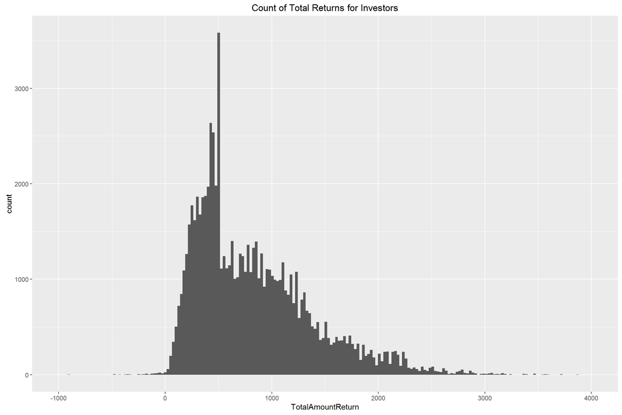

Comment: Investors have nearly received on average, $828 in return per loan  
Investors can possibly earn as high as $4,000. Interestingly, I’m seeing a large spike of investors earning $500. Notice though, that investors still can lose money as we see negative returns.

I would like to show the count of all loans of different prosper ratings…

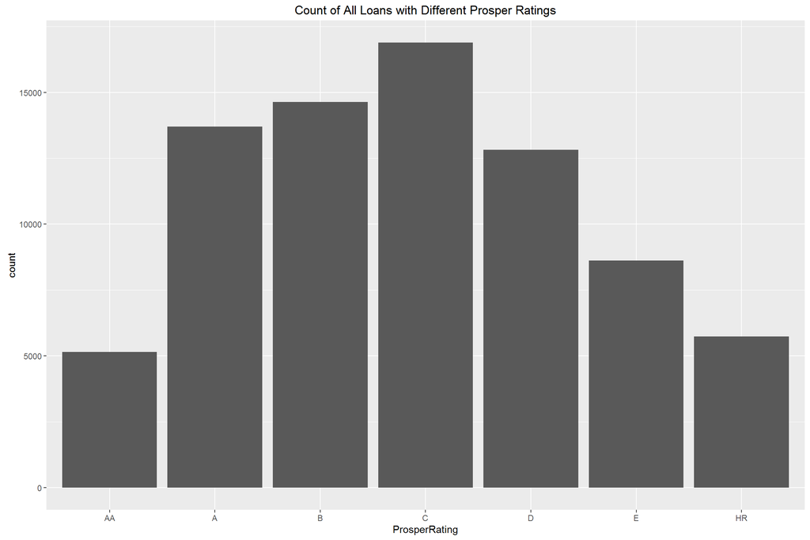

Comment: Most loans have a prosper rating of C

I would like a count of all loans with different estimated returns…

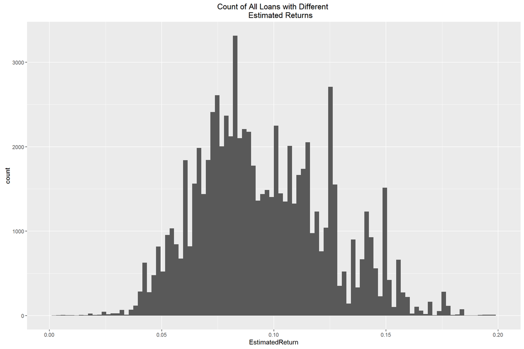

Comment: The average estimated return looks to be around 0.09

I would like a count of al loans with different numbers of borrower APRs…

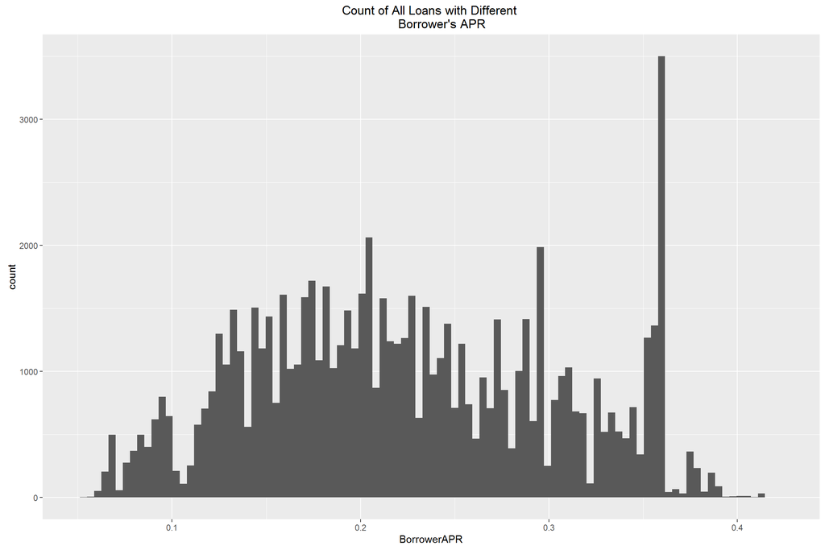

Comment: The average normal distribution looks to be at mean of 0.2.  
There is however a sudden big spike at around 0.36 APR.

I would like a count of all loans with different borrower’s credit score..

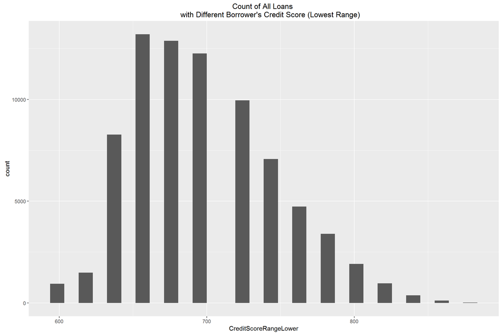

I would like a count of loan of all different amounts borrowed…

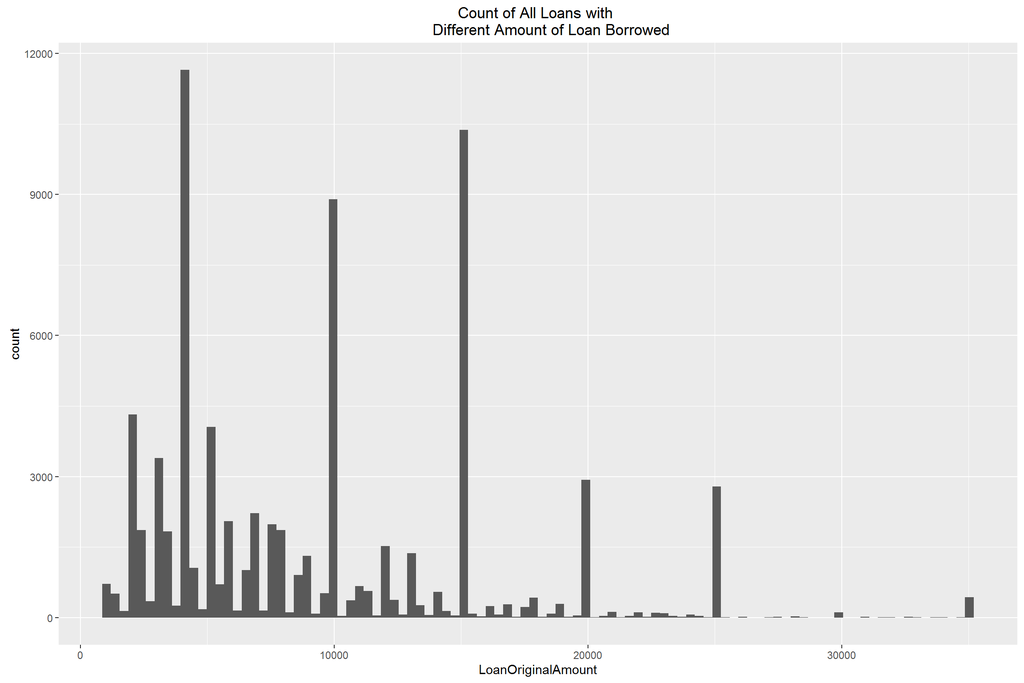

I would like a count of all loans with different debt to income ratio…

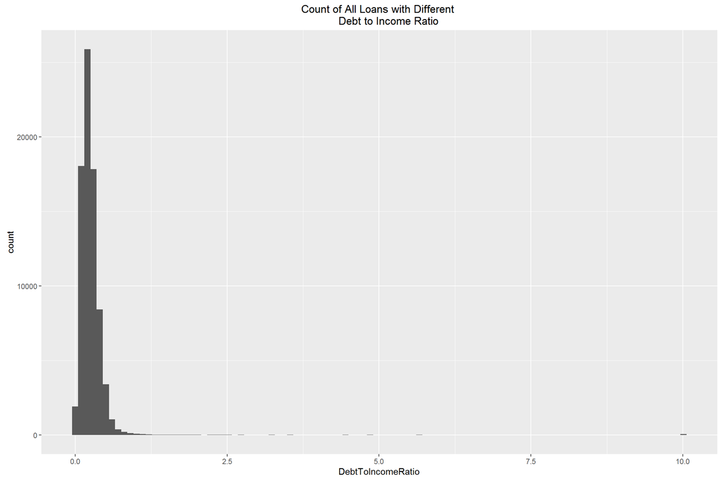

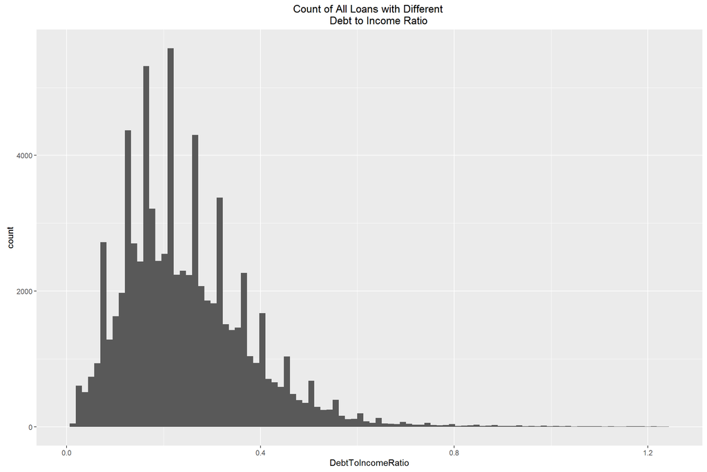

Comment: First, I want to point out the big outlier at the Debt to Income Ratio of 10, and anything in between around 1.2 to 10 looks to absolutely nothing.  
I then removed the bias by changing my x limit to between 0 and 1.25.  
I see that the average Debt to Income Ratio is about 0.2 . I also notice the large spikes in which my best guess is that borrowers just put in random numbers like 0.1, 0.2, etc.

In the next graph we will use log transform to see it more normally distributed

I would like a count of all loans with different debt to income ratio of log 10 because it looked very skewed before…

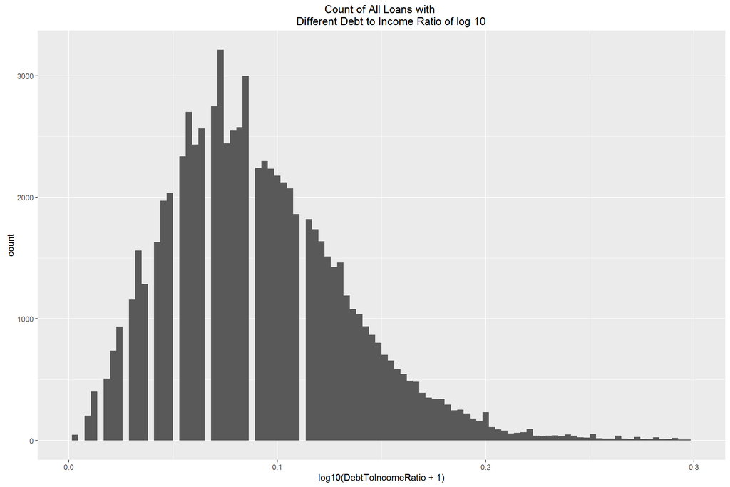

Comment: The average debt to income ratio appears to be around log of 0.09 but as the ratio becomes larger, the value of that ratio becomes more continuous ( Left half of the graph has more break lines than right half).

I would like a count of all loans with different loan statuses…

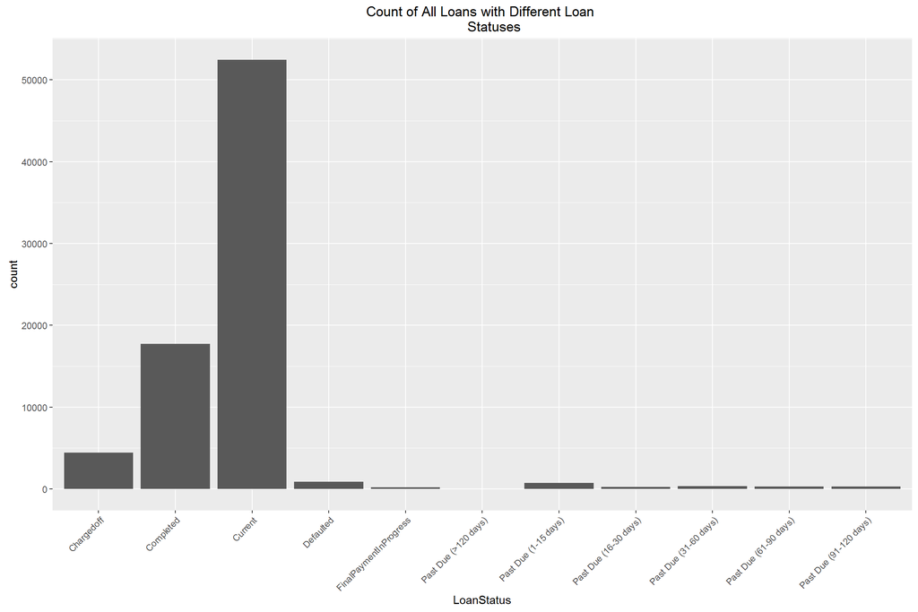

I would like a count of all loans with different borrower’s income range…

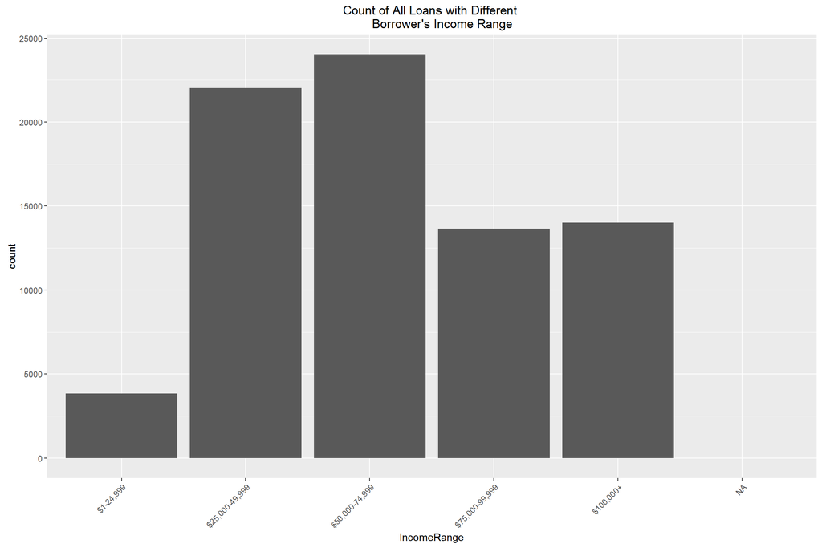

Comment: Most borrowers are between the income range of $50,000 and $74,999 I was hoping to see borrowers of income between $1 and $24,999 to be the highest because, they need to borrow more.

I would like a count of all loans with different terms

```
## Source: local data frame [3 x 2]
##
##    Term     n
##   (int) (int)
## 1    12  1414
## 2    36 53000
## 3    60 23143
```

Comment: A lot of people borrow a loan for 36 months.

# Univariate Analysis

### What is the structure of your dataset?

I stated what I found through different codes.

### What is/are the main feature(s) of interest in your dataset?

The main features in the data set are

EstimatedReturn: Because as Investors, we want to use the data to find the best return for our investment.

ProsperRating: And to determine what may be the way to invest for a return on our loans, the risk of a loan may have the most influence on a return out of all features.

### Did you create any new variables from existing variables in the dataset?

I created the total amount returned variable (“TotalAmountReturn”) using the code:

ld$TotalAmountReturn <- with(ld,EstimatedReturn*LoanOriginalAmount)

This function helps us to determine what an investor can expect to be returned from investing in that loan. We’re not only interested in percentage but the amount investors will receive.

### Of the features you investigated, were there any unusual distributions?

### Did you perform any operations on the data to tidy, adjust, or change the

### form of the data? If so, why did you do this?

# Bivariate Plots Section

I would like to see a box plot of all estimated return for each loans of different prosper ratings…

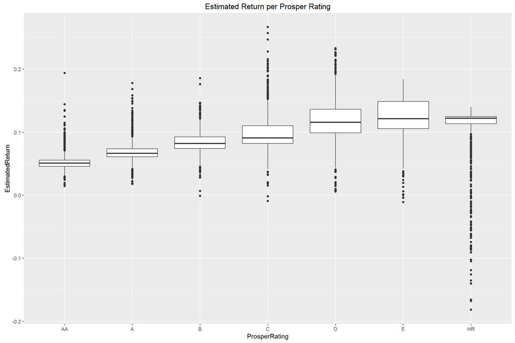

Comment:The average estimated return appears to increase as the Prosper Rating Risk increases. However, note the tails from one end changes amongst different risks. For example, we see more tails in “A” and they are above the 3rd Quantile and we see more tails in “HR” much below the 1st Quantile.

I would like a count of all estimated returns of differnet prosper ratings…

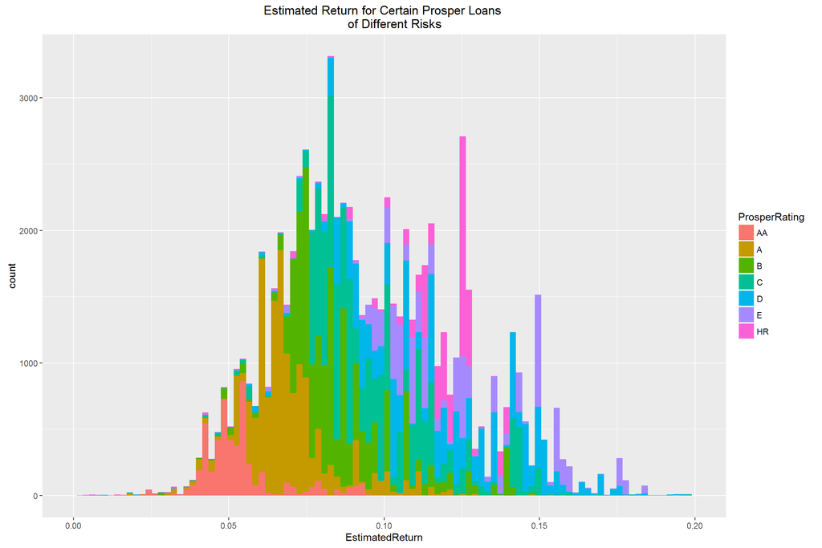

Comment:That we see a pattern. As the higher higher the estimated return, the higher the prosper rating risk showing up.

I would like to see the estimated returns of all borrowers of different credit score ranges…

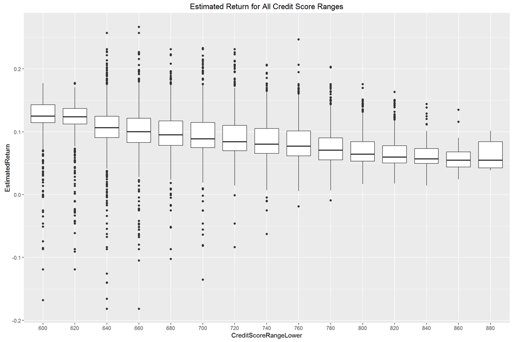

Comment: The investor’s estimated return decreases as borrower’s credit score increases. The Credit Score Range also follows the Prosper Rating.  
The lower the Credit Score, the higher the prosper rating score risk tends to be.

I would like to see how the typical borrower’s APR for each loan

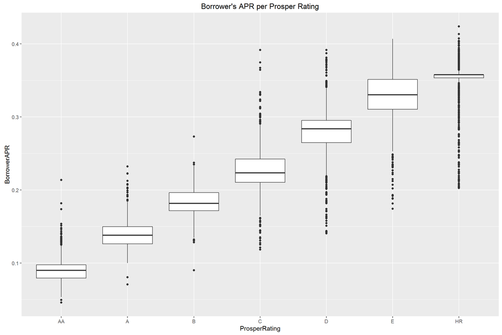

Comment:This box plot is a decision making tool for investors to invest in a certain APR in each Prosper Rating for greater gains. For example, in “C” rated loans, investor should only invest in those loans when Borrower APR is between 0.21 and 0.24.

I would like to see a boxplot of different estimated losses per each loan of different prosper ratings…

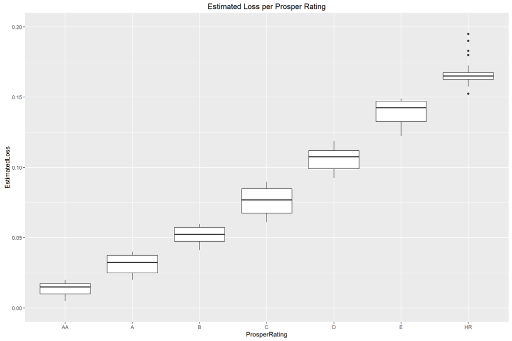

Comment: The higher one’s borrower rating is, the higher the estimated loss (unrecoverable money through charge offs) will be for us as investors

I would like to see a boxplot of different estimated losses for each loan status..

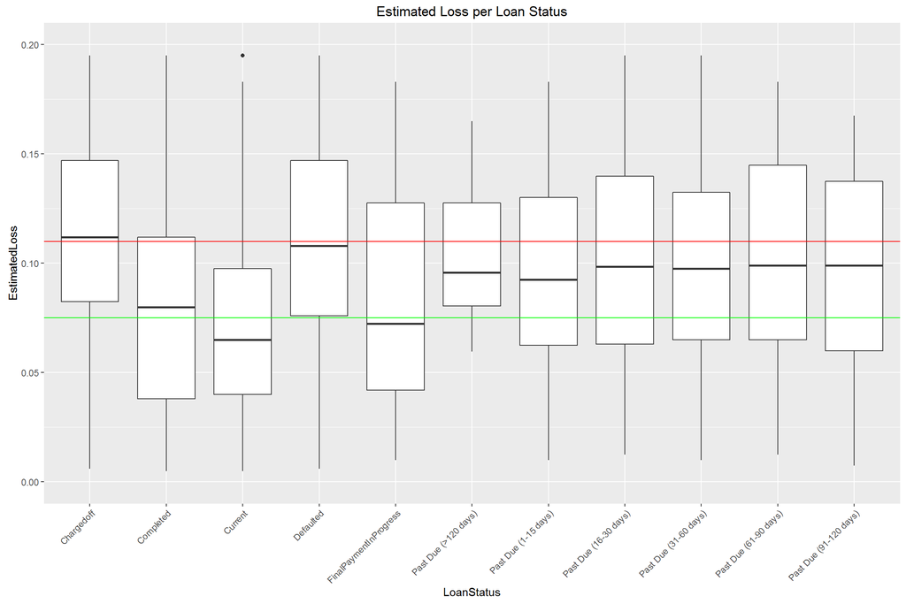

Comment:Loans that are charged off, defaulted, or past due usually have higher estimated losses to the investor Loans that are completed, current, and in the final payment progress are loans with less estimated losses

I would like to see a scatterplot of all different estimated returns of all different loan amounts…

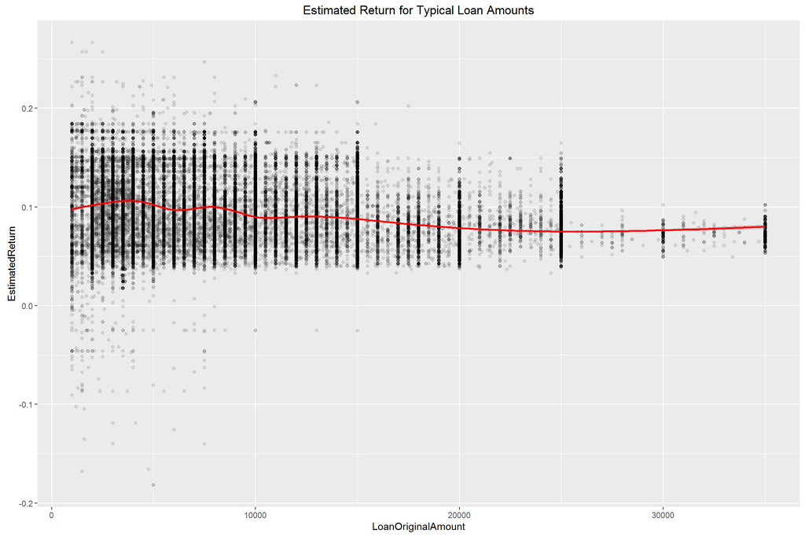

Comment: There is too much noise to conclude that the balance of the loan has any impact on the estimated return.

I would like to see a scatter plot of all different esimated returns from all different borrower APR.

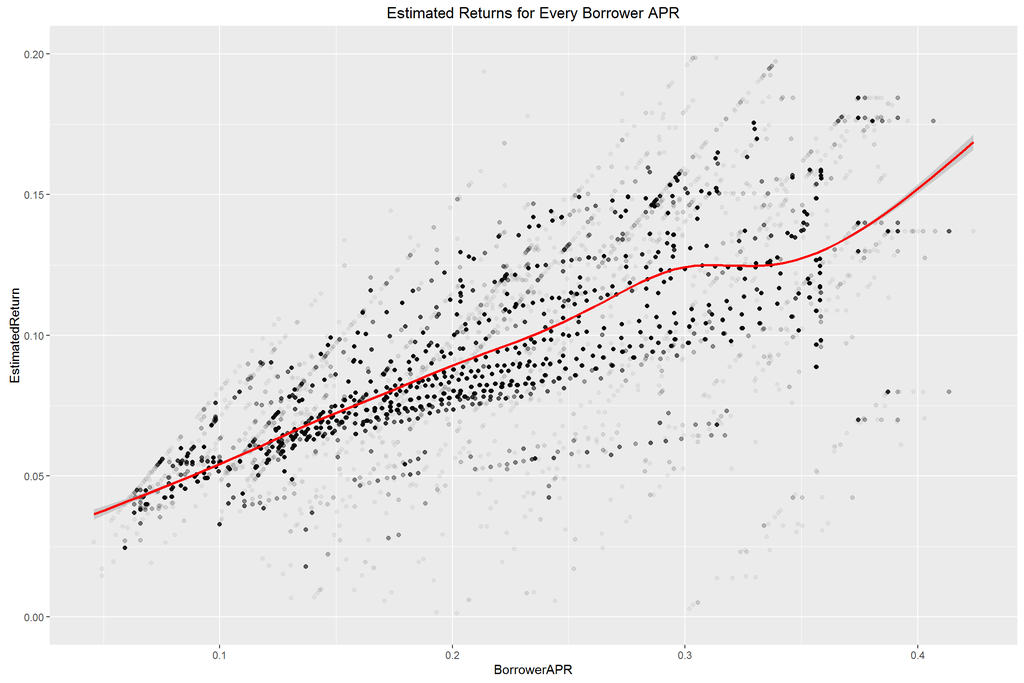

Comment:The estimated return does increase as the BorrowerAPR increases but variation also increases as well.

I would like to see a box plot of different credit score ranges of different loan statuses…

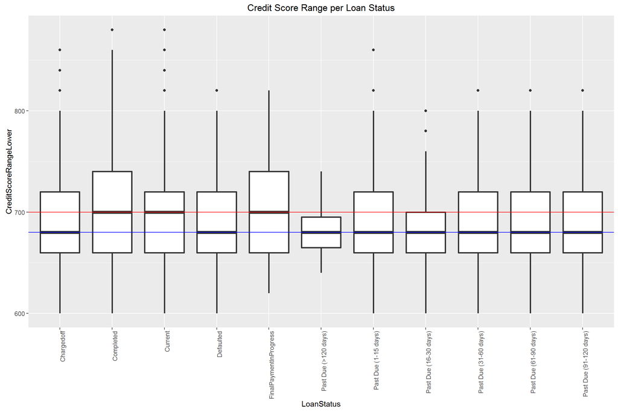

# Bivariate Analysis

### Talk about some of the relationships you observed in this part of the

### investigation. How did the feature(s) of interest vary with other features

### in the dataset?

The higher the Prosper Rating, the more likely higher the return (but more volatile)

The higher the Prosper Rating, the higher the estimated loss percentage.

The higher a borrower’s APR, the higher the investor’s individual return (but more volatile).

Loans that have been completed, currently going , and payments in final progress are loans in which borrowers have higher credit score than loans that have been canceled, charged off, and defaulted.

### Did you observe any interesting relationships between the other features

### (not the main feature(s) of interest)?

I notice that as the Prosper Rating risk increases, the spread for estimated return and loss increases. This makes sense because the higher the risk, the more likely a borrower can fail to repay back the loan thus resulting in charge off or default, and thus resulting in investors losing money.

### What was the strongest relationship you found?

The strong relationship I found usually involves between risks and rewards, the higher the risk of a borrower (lower credit core and higher prosper rating) , the higher the return but also higher the loss.

# Multivariate Plots Section

I would like to see the percentage of counts of loan statuses per every prosper rating loans…

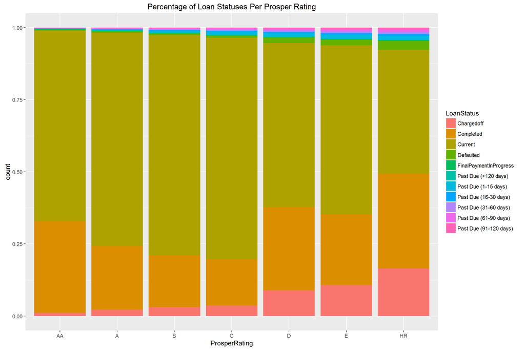

Comment:The higher the loan risk, the more likely the loan will end up being charged off and defaulted. And also more likely borrowers will fail to pay on time.

I would like to see the percentage of borrower’s income range for all prosper rating loans…

[figure not shown]

Comment:The higher the borrower’s income, the more likely their loans would be lower risk. The lower one’s income range, the more percentage their loans would be higher risk. It’s probably because a borrower with in the lower income range would most likely have sufficient income to pay back the loan thus putting that borrower at a higher risk.

I would like to see the percentage of income range for different loan statuses..

[figure not shown]

Comment:The lower one’s income range, the more likely their loans would be charged off, defaulted and have late payments

I would like to see different graphs of different correlations between, borrower’s credit score, income range, and prosper rating..

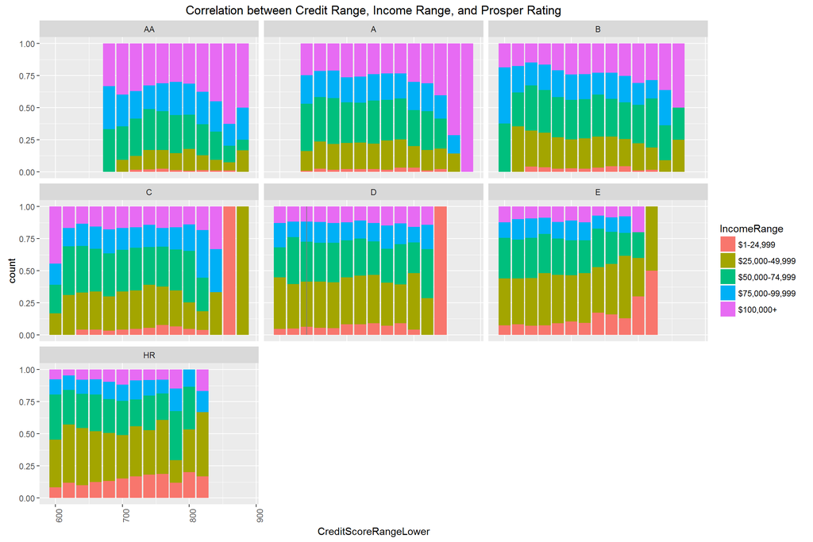

Comment:The higher the risk of a prosper loan, the more likely the borrower’s income range will be lower (as we start to see more brown, pink, and brown bars) and the borrower’s credit score will be lower (the bar chart seem to be shifting to the left as the prosper rating increases).

I would like to see the estimated return of from each loan of different borrower’s APR and prosper rating…

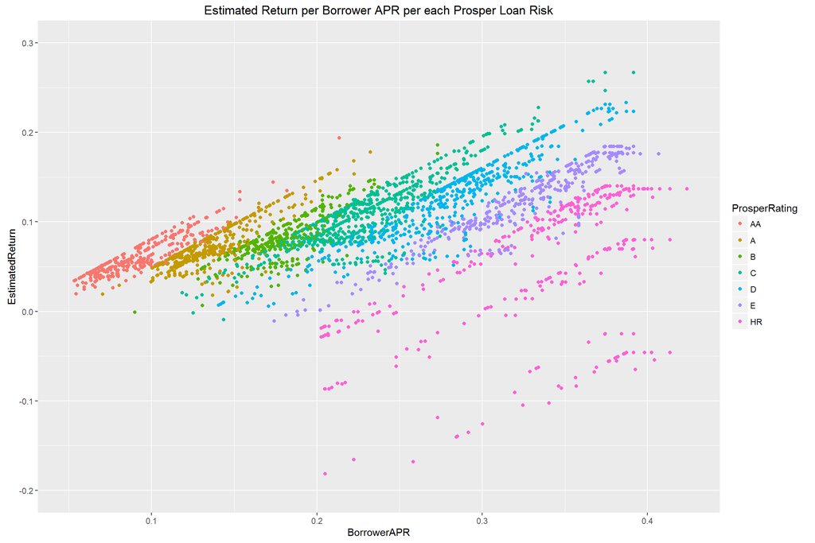

Comment:We see that different prosper ratings are directly stacked on top of each other. We can use this data as an advantage for investors to decide on which loans for optimal returns.

I would like to see an average moving line through different estimated returns through borrower’s APR and prosper rating loans…

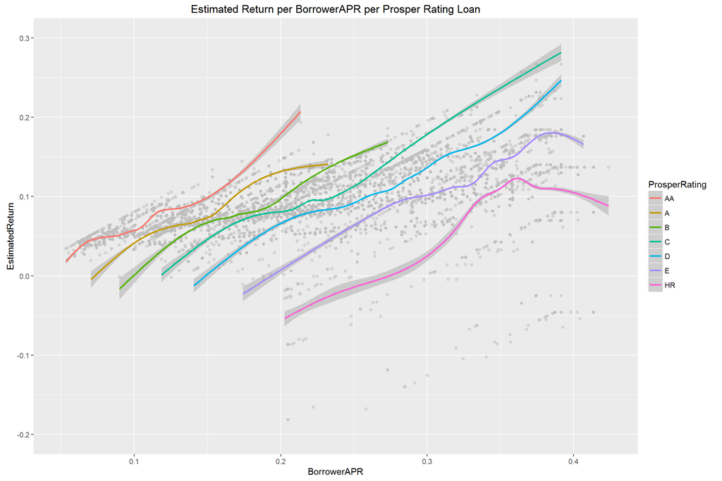

Comment:That we see the averages of each ratings do not intersect one another. Therefore, I see a pattern..

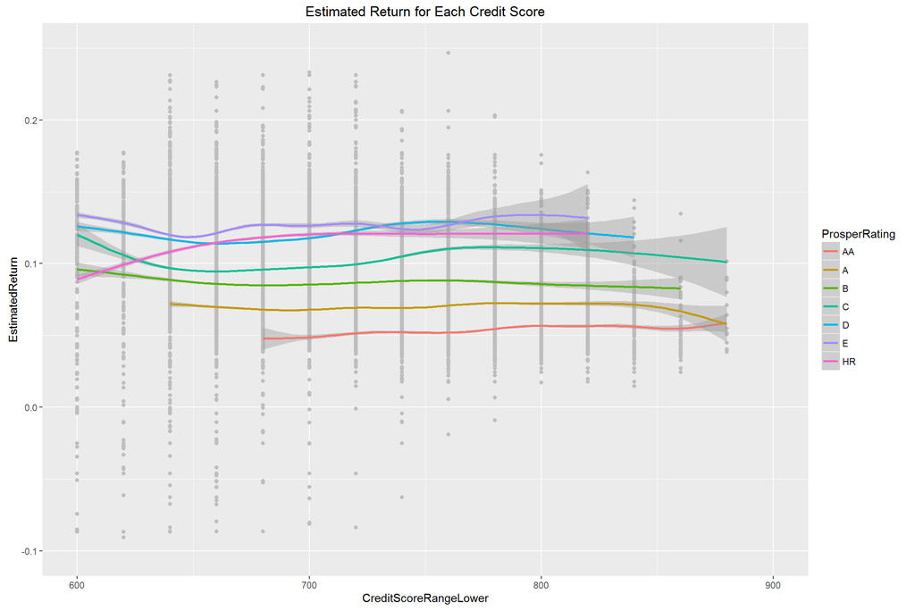

Comment:It’s difficult to determine which Prosper Rating to invest at different Credit Scores. The variance is also too high and other factors are more important to contribute the decision.

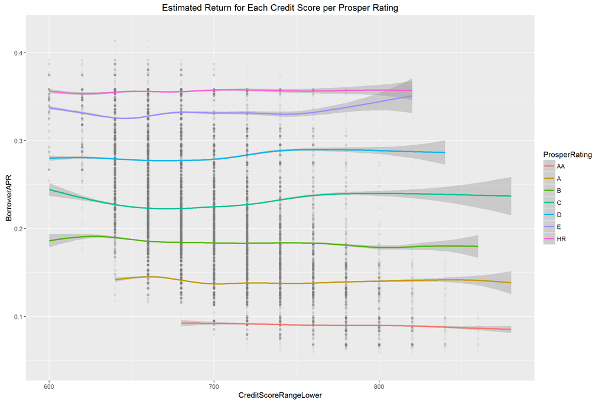

Comment:There appears to be a consistent horizontal pattern for each Prosper Rating. By consistency, the higher the rating of a loan, the higher and consistent the borrower’s APR.

I would like to see total amount returned (estimated return times loan original amount) for each prosper rating…

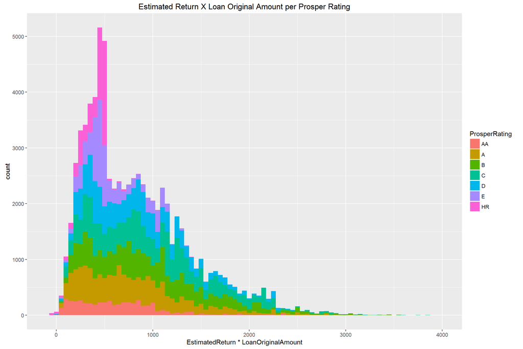

Comment:At most, an investor can make almost $4000 on a loan. We see that an invstor investing in HR can struggle to make more than $1000 in return.

I would like to see investor’s total return (estimated return times loan original amount) for each term…

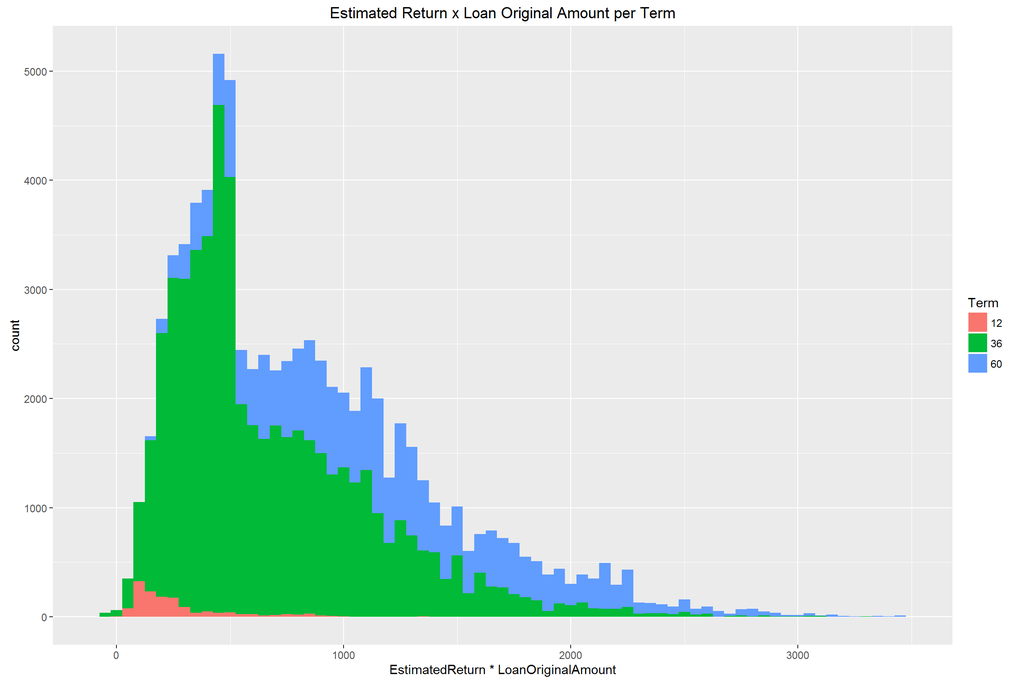

Comment: Investing in longer term can yield more earnings to the investor

I would like to see all investor’s total return (estimated return times loan original amount) at each prosper rating at different credit score…

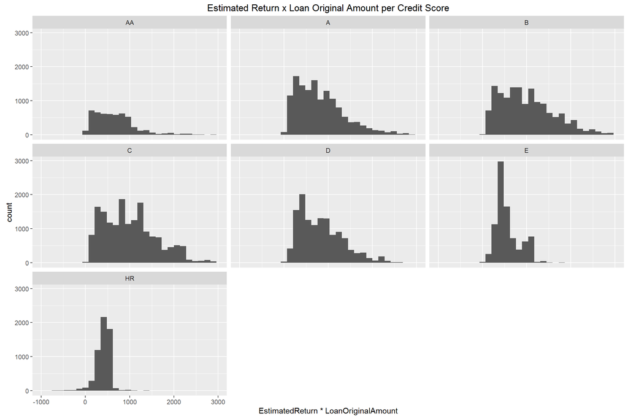

I would like to see all investor’s total return (estimated return times loan original amount) at each prosper rating at different loan terms…

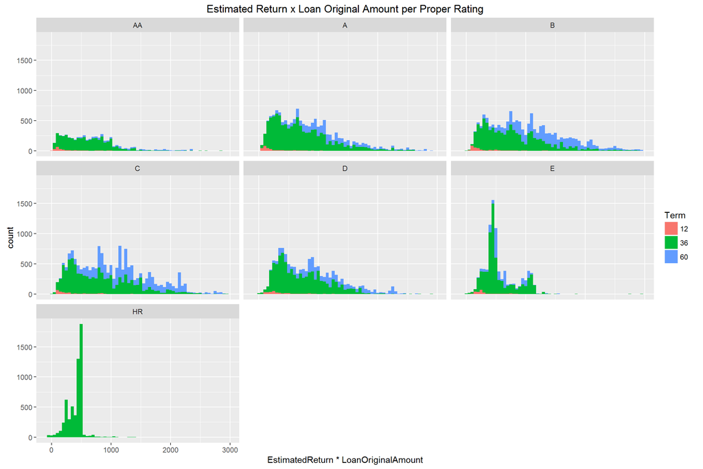